# Sentiment analysis of love songs

This tutorial is based on the following references: * https://www.datacamp.com/community/tutorials/R-nlp-machine-learning * https://www.datacamp.com/community/tutorials/sentiment-analysis-R#descriptivestatistics

## Getting song lyrics

First we need to find some song lyrics. We can use the [awesome genius package from Josiah Parry](https://github.com/JosiahParry/genius). Let’s install that and load all the necessary libraries

```r
#devtools::install_github("josiahparry/genius")
library(genius)
library(tidyverse)
library(readr)
library(tidytext)
library(knitr)
library(formattable)
library(kableExtra)
library(gridExtra)
library(wordcloud2)
library(circlize)
```

The website theknot.com has prepared a [list of the top 100 love songs](https://www.theknot.com/content/best-love-songs). This goes across different music genre, from the good old classics to more modern stuff. So it seems like a great sample of love songs we can use to find out what a love song is made of. To speed things up I’ve already prepared a table with the name of the tracks and the artists that recorded them. But you can always go back to our previous webscraping tutorial to see how you could create the table yourself. Let’s load the file with our love song info:

```r
top100love <- read_csv("top100love.csv")
```

We can use this table along with the genius package to download the lyrics to all these songs. Since that takes a bit of time I’ve already done it and saved the results in the provided songs.RData file, so we can just load that instead.

Here are the commands to download songs yourself:

```r
#top100love_lyrics <- top100love %>%
#    add_genius(artist = artist, type_group = track, type = "lyrics")
# Note: a few of the songs were not available on genius
```

As a comparison group, let’s also download the top 100 songs from genius. These are likely to also be a mix of genre, but we don’t expect it’ll be particularly enriched for love songs.

We’ll import the table with those tracks and use genius to grab the lyrics:

```r
#top100 <- read_csv("top100.csv")
#top100_lyrics <- top100 %>%
#    add_genius(artist = artist, type_group = track, type = "lyrics")
```

Just to load the data from these commands we can use:

```r
# How I saved it:
#save(top100_lyrics, top100love_lyrics, file = "songs.RData")
load("songs.RData")
```

Let’s check how many tracks genius actually found for each of our datasets:

```r
top100_lyrics %>%
    group_by(artist, track) %>%
    count() %>%
    nrow()
```

```
[1] 86
```

```r
top100love_lyrics %>%
    group_by(artist, track) %>%
    count() %>%
    nrow()
```

```
[1] 87
```

## Clean up time!

We’ll begin by removing stuff from our environment:

```r
rm(top100)
```

```
object 'top100' not found
```

```r
rm(top100love)
```

First, get rid of contractions by creating a little function that handles most scenarios using gsub().

```r
fix.contractions <- function(doc) {
  doc <- gsub("won't", "will not", doc)
  doc <- gsub("can't", "can not", doc)
  doc <- gsub("n't", " not", doc)
  doc <- gsub("'ll", " will", doc)
  doc <- gsub("'re", " are", doc)
  doc <- gsub("'ve", " have", doc)
  doc <- gsub("'m", " am", doc)
  doc <- gsub("'d", " would", doc)
  doc <- gsub("'s", "", doc)
  doc <- gsub("in'", "ing", doc)
  return(doc)
}
top100_lyrics$lyric <- sapply(top100_lyrics$lyric, fix.contractions)
top100love_lyrics$lyric <- sapply(top100love_lyrics$lyric, fix.contractions)
```

You’ll also notice special characters that muddy the text. You can remove those with the gsub() function and a simple regular expression. Notice it’s critical to expand contractions before doing this step!

```r
# function to remove special characters (match any character not in the set below)
removeSpecialChars <- function(x) gsub("[^a-zA-Z0-9 ]", " ", x)
top100_lyrics$lyric <- sapply(top100_lyrics$lyric, removeSpecialChars)
top100love_lyrics$lyric <- sapply(top100love_lyrics$lyric, removeSpecialChars)
# convert everything to lower case
top100_lyrics$lyric <- sapply(top100_lyrics$lyric, tolower)
top100love_lyrics$lyric <- sapply(top100love_lyrics$lyric, tolower)
```

One more step in cleaning the data. Many lyrics can include phrases like “Repeat Chorus”, or labels such as “Bridge” and “Verse”. Let’s get some of that out of the way. For now we’ll create a list of these undesirable words to use in the next fe steps. As we progress with the analysis we can always come back and add more elements here.

```r
undesirable_words <- c("chorus", "repeat", "lyrics", "bridge",
                       "verse", "transcription", "repeats")
```

## Tidy Text Format

To begin the analysis, you need to break out the lyrics into individual words. This process is called tokenization. Tidy Text: a table with one token per row. In this case study, a token will be a word. Tokenization is therefore the process of splitting the lyrics into tokens. This tutorial will use tidytext’s unnest_tokens() to do this. We’ll also use this chance to remove our undesired words above and some common stop words that don’t add much meaning to our sentiment analysis (such as: the, and, this, how, etc).

```r
top100filtered <- top100_lyrics %>%
  unnest_tokens(word, lyric) %>% # unnest_tokens() requires at least two arguments: the output column name that will be created ("word", in this case), and the input column that holds the current text (lyrics).
  anti_join(stop_words) %>% # This removes the most common stop words
  filter(!word %in% undesirable_words) # Remove our undesired words
top100lovefiltered <- top100love_lyrics %>%
  unnest_tokens(word, lyric) %>%
  anti_join(stop_words) %>%
  filter(!word %in% undesirable_words)
```

Well we can already see from the size of our tables that we seem to have way less words in our love songs. Let’s check if that’s true.

```r
length(unique(top100filtered$word))
```

```
[1] 4678
```

```r
length(unique(top100lovefiltered$word))
```

```
[1] 1307
```

```r
cbind(top100lovefiltered %>%
  filter(word == "love") %>% # Look at only songs that have the word love
  select(word, track, artist) %>%
  distinct() %>% # remove duplicate records
  count(name = "love"),
top100filtered %>%
  filter(word == "love") %>% # Look at only songs that have the word love
  select(word, track, artist) %>%
  distinct() %>% # remove duplicate records
  count(name = "all"))
```

| love | all |
| --- | --- |
| 61 | 51 |

We can see the songs that have the word love in a pretty table too:

```r
top100lovefiltered %>%
  filter(word == "love") %>% # Look at only songs that have the word love
  select(word, track, artist) %>% # choose columns to view
  arrange() %>% # order the table rows
  distinct() %>% # remove duplicate records
  #top_n(10,track) %>% #could be used to see top 10 songs only
  mutate(track = color_tile("lavenderblush","lavenderblush")(track)) %>% # if numeric data, could be gradient between 2 colors.
  mutate(word = color_tile("lightpink","lightpink")(word)) %>%
  kable(escape = FALSE, align = "c", caption = "Tokenized Format Example") %>% # makes the table look nicer
  kable_styling(bootstrap_options =
                  c("striped", "condensed", "bordered"), # makes the white/grey row color, reduce the padding and add a border to the table.
                  full_width = FALSE)
```

```
NAs introduced by coercionNAs introduced by coercion
```

Tokenized Format Example

| word | track | artist |
| --- | --- | --- |
| love | In Your Eyes | Peter Gabriel |
| love | Unchained Melody | the Righteous Brothers |
| love | The First Time Ever I Saw Your Face | Roberta Flack |
| love | I Will Always Love You | Whitney Houston |
| love | When a Man Loves a Woman | Percy Sledge |
| love | My Love | Paul McCartney and Wings |
| love | Best of My Love | The Emotions |
| love | Endless Love | Diana Ross and Lionel Richie |
| love | The Power of Love | Celine Dion |
| love | I Want to Know What Love Is | Foreigner |
| love | You Are the Sunshine of My Life | Stevie Wonder |
| love | I Love You Always Forever | Donna Lewis |
| love | Up Where We Belong | Joe Cocker and Jennifer Warnes |
| love | I Keep on Lovin' You | Reba McEntire |
| love | Through the Years | Kenny Rogers |
| love | Remember When | Alan Jackson |
| love | When I Said I Do | Clint Black and Lisa Hartman Black |
| love | I Will Always Love You | Dolly Parton |
| love | Making Memories of Us | Keith Urban |
| love | Forever and Ever, Amen | Randy Travis |
| love | Amazed | Lonestar |
| love | Love, Me | Collin Raye |
| love | I Cross My Heart | George Strait |
| love | Two Sparrows in a Hurricane | Tanya Tucker |
| love | To Make You Feel My Love | Garth Brooks |
| love | Crazy Little Thing Called Love | Queen |
| love | When You Love a Woman | Journey |
| love | True Love Waits | Radiohead |
| love | Whole Lotta Love | Led Zeppelin |
| love | Love of My Life | Queen |
| love | Is This Love? | Whitesnake |
| love | Something | the Beatles |
| love | Faithfully | Journey |
| love | Sleepwalking | Modest Mouse |
| love | Still Together | Mac DeMarco |
| love | Inside and Out | Feist |
| love | I Will Keep the Bad Things from You | The Damnwells |
| love | Fix You | Coldplay |
| love | The Luckiest | Ben Folds |
| love | Dog Days Are Over | Florence and the Machine |
| love | Just Like Heaven | The Cure |
| love | Make You Feel My Love | Adele |
| love | Love Song | Sara Bareilles |
| love | Bless the Broken Road | Rascal Flatts |
| love | Bleeding Love | Leona Lewis |
| love | Love Story | Taylor Swift |
| love | Pusher Love Girl | Justin Timberlake |
| love | Adore You | Miley Cyrus |
| love | The Best | Tina Turner |
| love | As Long As I Got You | Lily Allen |
| love | Cherish | Madonna |
| love | I Have Been Around the World | Dar Williams |
| love | If I Never Met You | Barbra Streisand |
| love | The Man with the Child in His Eyes | Kate Bush |
| love | Magic Man | Heart |
| love | Lady | Kenny Rogers |
| love | The Lady in Red | Chris de Burgh |
| love | Wonderful Tonight | Eric Clapton |
| love | When a Man Loves a Woman | Michael Bolton |
| love | (Everything I Do) I Do it For You | Bryan Adams |
| love | Take My Breath Away | Berlin |

```r
#Customize the text tables for consistency using HTML formatting
my_kable_styling <- function(dat, caption) {
  kable(dat, "html", escape = FALSE, caption = caption) %>%
  kable_styling(bootstrap_options = c("striped", "condensed", "bordered"),
                full_width = FALSE)
}
```

```r
top100filtered %>%
  filter(word == "love") %>% # Look at only songs that have the word love
  select(word, track, artist) %>% # choose columns to view
  arrange() %>% # order the table rows
  distinct() %>% # remove duplicate records
  #top_n(10,track) %>% #could be used to see top 10 songs only
  mutate(track = color_tile("lavenderblush","lavenderblush")(track)) %>% # if numeric data, could be gradient between 2 colors.
  mutate(word = color_tile("lightpink","lightpink")(word)) %>%
  my_kable_styling("Tokenized format example")
```

```
NAs introduced by coercionNAs introduced by coercion
```

Tokenized format example

| word | track | artist |
| --- | --- | --- |
| love | Despacito (Remix) | Luis Fonsi & Daddy Yankee |
| love | Shape of You | Ed Sheeran |
| love | The Hills | The Weeknd |
| love | _thank u, next | Ariana Grande |
| love | Work | Rihanna |
| love | Too Good at Goodbyes | Sam Smith |
| love | Fuckin' Problems | A$AP Rocky |
| love | In My Feelings | Drake |
| love | Hotline Bling | Drake |
| love | SICKO MODE | Travis Scott |
| love | Trap Queen | Fetty Wap |
| love | Holy Grail | JAY-Z |
| love | SAD! | XXXTENTACION |
| love | Starboy | The Weeknd |
| love | One Dance | Drake |
| love | Killshot | Eminem |
| love | Swimming Pools (Drank) | Kendrick Lamar |
| love | Perfect | Ed Sheeran |
| love | _i_ hate u, i love u | _gnash |
| love | Look At Me! | XXXTENTACION |
| love | FRIENDS | Marshmello & Anne-Marie |
| love | Bohemian Rhapsody | Queen |
| love | Back to Back | Drake |
| love | Hot Nigga | Bobby Shmurda |
| love | Black Beatles | Rae Sremmurd |
| love | Money Trees | Kendrick Lamar |
| love | XXX. | Kendrick Lamar |
| love | Control | Big Sean |
| love | The Monster | Eminem |
| love | Gucci Gang | Lil Pump |
| love | New Rules | Dua Lipa |
| love | Poetic Justice | Kendrick Lamar |
| love | No Role Modelz | J. Cole |
| love | Lose Yourself | Eminem |
| love | Believer | Imagine Dragons |
| love | All Me | Drake |
| love | MotorSport | Migos, Nicki Minaj & Cardi B |
| love | _goosebumps | Travis Scott |
| love | Bad | Wale |
| love | Fake Love | Drake |
| love | Power Trip | J. Cole |
| love | Guns and Ships | Original Broadway Cast of Hamilton |
| love | Love Yourself | Justin Bieber |
| love | See You Again | Wiz Khalifa |
| love | Monster | Kanye West |
| love | Attention | Charlie Puth |
| love | Lucky You | Eminem |
| love | 0 to 100 / The Catch Up | Drake |
| love | LOVE. | Kendrick Lamar |
| love | From Time | Drake |
| love | Same Love | Macklemore & Ryan Lewis |

Is it true that love and hate are much closer than we think? How many love songs also mention hate? None!

```r
cbind(top100lovefiltered %>%
  filter(word == "hate") %>% # Look at only songs that have the word love
  select(word, track, artist) %>%
  distinct() %>% # remove duplicate records
  count(name = "love"),
top100filtered %>%
  filter(word == "hate") %>% # Look at only songs that have the word love
  select(word, track, artist) %>%
  distinct() %>% # remove duplicate records
  count(name = "all"))
```

| love | all |
| --- | --- |
| 0 | 14 |

Now let’s see how many words we have in our songs, are love songs in general longer or shorter than the rest?

We recreate the word counts without any filter for this. First our regular songs. Looks like Eminem knows how to use his words!

```r
top100unfilt <- top100_lyrics %>%
  unnest_tokens(word, lyric) %>%
  group_by(track, artist) %>%
  summarise(num_words = n()) %>%
  arrange(desc(num_words))
top100unfilt[1:10,] %>%
  ungroup(num_words, track) %>%
  mutate(num_words = color_bar("lightblue")(num_words)) %>%
  mutate(track = color_tile("lightgreen","lightgreen")(track)) %>%
  my_kable_styling("Songs with highest word count")
```

```
NAs introduced by coercion
```

Songs with highest word count

| track | artist | num_words |
| --- | --- | --- |
| Rap God | Eminem | 1620 |
| Control | Big Sean | 1455 |
| Bad and Boujee | Migos | 1221 |
| Lucky You | Eminem | 1208 |
| Mercy | Kanye West | 1161 |
| Money Trees | Kendrick Lamar | 1085 |
| All Me | Drake | 1078 |
| Monster | Kanye West | 1063 |
| Killshot | Eminem | 1059 |
| 0 to 100 / The Catch Up | Drake | 1016 |

Now for the love songs:

```r
top100loveunfilt <- top100love_lyrics %>%
  unnest_tokens(word, lyric) %>%
  group_by(track, artist) %>%
  summarise(num_words = n()) %>%
  arrange(desc(num_words))
top100loveunfilt[1:10,] %>%
  ungroup(num_words, track) %>%
  mutate(num_words = color_bar("lightblue")(num_words)) %>%
  mutate(track = color_tile("lightgreen","lightgreen")(track)) %>%
  my_kable_styling("Songs with highest word count")
```

```
NAs introduced by coercion
```

Songs with highest word count

| track | artist | num_words |
| --- | --- | --- |
| Pusher Love Girl | Justin Timberlake | 795 |
| Cherish | Madonna | 530 |
| The Power of Love | Celine Dion | 526 |
| Bitter Sweet Symphony | The Verve | 461 |
| Love Song | Sara Bareilles | 439 |
| Inside and Out | Feist | 406 |
| Bleeding Love | Leona Lewis | 390 |
| Love Story | Taylor Swift | 389 |
| I Love You Always Forever | Donna Lewis | 376 |
| In Your Eyes | Peter Gabriel | 371 |

It sure looks like love doesn’t need as many words.

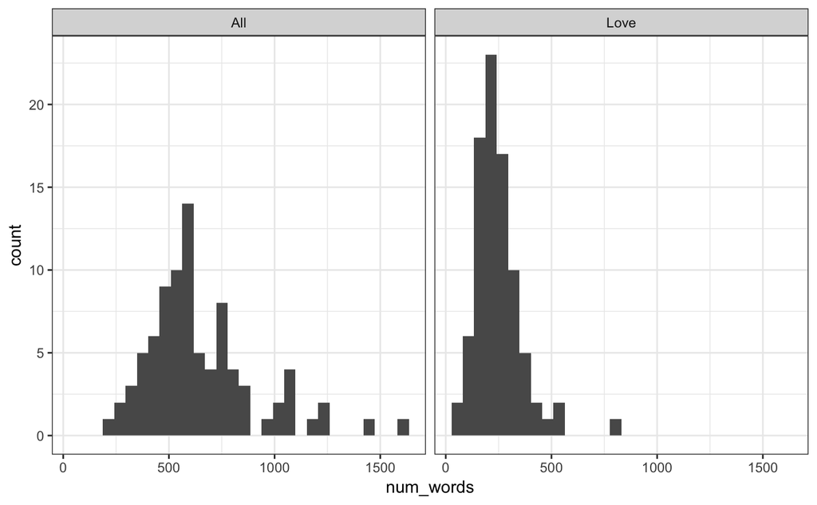

```r
rbind(top100unfilt %>%
        mutate(type = "All"),
    top100loveunfilt %>%
        mutate(type = "Love")) %>%
    ggplot(aes(num_words)) + geom_histogram() + facet_wrap(. ~ type) + theme_bw()
```

In order to do a simple evaluation of the most frequently used words in the full set of lyrics, you can use count() and top_n() to get the n top words from your clean, filtered dataset. Then use reorder() to sort words according to the count and use dplyr’s mutate() verb to reassign the ordered value to word. This allows ggplot() to display it nicely.

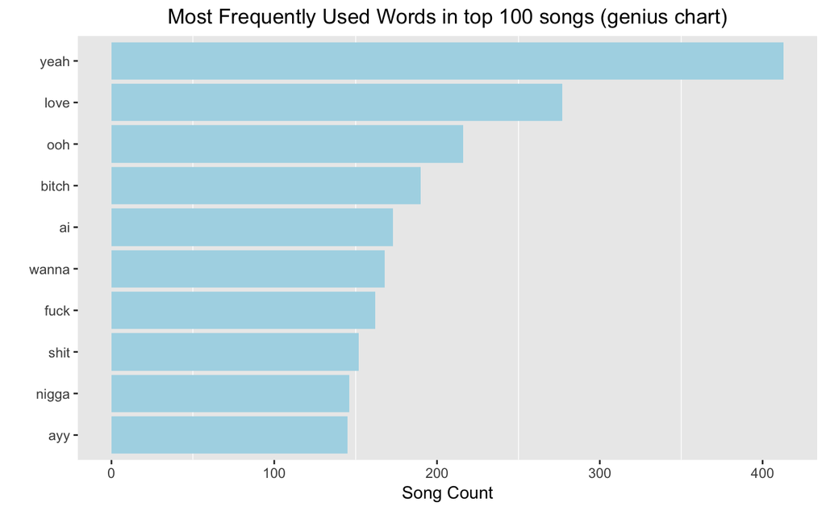

```r
top100filtered %>%
  count(word, sort = TRUE) %>%
  top_n(10) %>%
  ungroup() %>%
  mutate(word = reorder(word, n)) %>%
  ggplot() +
    geom_col(aes(word, n), fill = "lightblue") +
    theme(legend.position = "none",
          plot.title = element_text(hjust = 0.5),
          panel.grid.major = element_blank()) +
    xlab("") +
    ylab("Song Count") +
    ggtitle("Most Frequently Used Words in top 100 songs (genius chart)") +
    coord_flip()
```

Well, definetely not the top 10 words I’d normally use…

Now for our love songs:

[figure not shown]

```r
top100lovefiltered %>%
  count(word, sort = TRUE) %>%
  top_n(10) %>%
  ungroup() %>%
  mutate(word = reorder(word, n)) %>%
  ggplot() +
    geom_col(aes(word, n), fill = "lightpink") +
    theme(legend.position = "none",
          plot.title = element_text(hjust = 0.5),
          panel.grid.major = element_blank()) +
    xlab("") +
    ylab("Song Count") +
    ggtitle("Most Frequently Used Words in top 100 songs (genius chart)") +
    coord_flip()
```

Love sure reigns supreme here.

## Word cloud

Just for fun let’s do some word clouds from our songs.

```r
all_words_counts <- top100filtered %>%
  count(word, sort = TRUE)
love_words_counts <- top100lovefiltered %>%
  count(word, sort = TRUE)
wordcloud2(all_words_counts[1:300, ], size = 2)
```

[interactive chart not shown]

```r
wordcloud2(love_words_counts[1:300, ], size = 2, color = "white", backgroundColor = "hotpink", shape = "caroid")
```

[interactive chart not shown]

```r
# The 2 below only work in the console:
#wordcloud2(love_words_counts[1:300, ], figPath = "heart.png", backgroundColor = "hotpink", color = "white", size = 3)
#letterCloud(love_words_counts[1:300, ], word = "LOVE", size = 4)
```

## Lexical diversity and density:

The more varied a vocabulary a text possesses, the higher its lexical diversity. Song Vocabulary is a representation of how many unique words are used in a song.

Lexical density is an indicator of word repetition, which is a critical songwriter’s tool. As lexical density increases, repetition decreases.

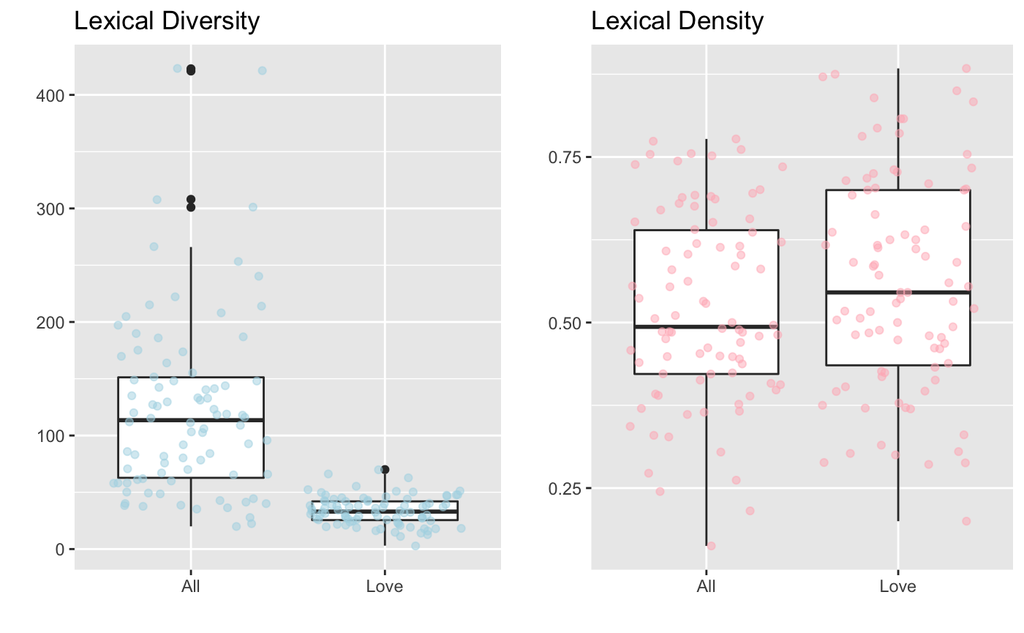

```r
All_songs_filtered <- rbind(top100filtered %>%
        mutate(type = "All"),
    top100lovefiltered %>%
        mutate(type = "Love"))
lex_diversity <- All_songs_filtered %>%
  group_by(track,artist,type) %>%
  summarise(lex_diversity = n_distinct(word)) %>%
  arrange(desc(lex_diversity))
diversity_plot <- lex_diversity %>%
  ggplot(aes(type, lex_diversity)) +
    geom_boxplot() +
    geom_jitter(color = "lightblue", alpha = .5) +
    ggtitle("Lexical Diversity") +
    xlab("") +
    ylab("")
lex_density <- All_songs_filtered %>%
  group_by(track,artist,type) %>%
  summarise(lex_density = n_distinct(word)/n()) %>%
  arrange(desc(lex_density))
density_plot <- lex_density %>%
  ggplot(aes(type, lex_density)) +
    geom_boxplot() +
    geom_jitter(color = "lightpink", alpha = .5) +
    ggtitle("Lexical Density") +
    xlab("") +
    ylab("")
grid.arrange(diversity_plot, density_plot, ncol = 2)
```

Love songs definitely seem to have less lexical diversity, but this could just be because we are comparing them overal top 100 songs, that will likely emcompass different genre of music. How about you try to make this comparison for different genre, like country, pop, rock, etc. I bet rap songs are going to score really high on both parameters above.

## TF-IDF

A very cool concept in text analysis is TF-IDF. Here is where this comes from:

So this is going to help us find words that are over-represented in a given document when compared to other documnets in a collection.

Let’s beging by looking at this concept when we compare all love songs to our list of top 100 most popular songs. For this we’ll still remove the undesired words but leave the stop words. We expect the stop words should happen often in all types of music, so they’ll have a low TF-IDF.

```r
All_songs <- rbind(top100_lyrics %>%
        mutate(type = "All"),
    top100love_lyrics %>%
        mutate(type = "Love"))
popular_tfidf_words <- All_songs %>%
  unnest_tokens(word, lyric) %>%
  distinct() %>%
  filter(!word %in% undesirable_words) %>%
  filter(nchar(word) > 3) %>%
  count(type, word, sort = TRUE) %>%
  ungroup() %>%
  bind_tf_idf(word, type, n)
head(popular_tfidf_words)
```

| type | word | n | tf | idf | tf_idf |
| --- | --- | --- | --- | --- | --- |
| All | that | 767 | 0.03036902 | 0 | 0 |
| Love | love | 399 | 0.03964232 | 0 | 0 |
| All | like | 397 | 0.01571904 | 0 | 0 |
| All | your | 388 | 0.01536269 | 0 | 0 |
| All | with | 357 | 0.01413525 | 0 | 0 |
| All | yeah | 321 | 0.01270985 | 0 | 0 |

```
`show.legend` must be a logical vector.
```

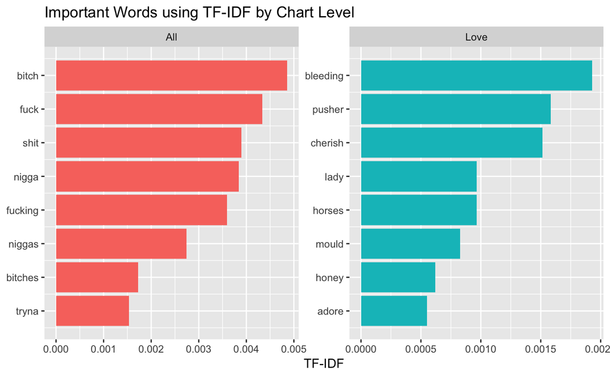

```r
top_popular_tfidf_words <- popular_tfidf_words %>%
  arrange(desc(tf_idf)) %>%
  mutate(word = factor(word, levels = rev(unique(word)))) %>%
  group_by(type) %>%
  slice(seq_len(8)) %>%
  ungroup() %>%
  arrange(type, tf_idf) %>%
  mutate(row = row_number())
top_popular_tfidf_words %>%
  ggplot(aes(x = row, tf_idf,
             fill = type)) +
    geom_col(show.legend = NULL) +
    labs(x = NULL, y = "TF-IDF") +
    ggtitle("Important Words using TF-IDF by Chart Level") +
    facet_wrap(~type, ncol = 3, scales = "free") +
    scale_x_continuous(  # This handles replacement of row
    breaks = top_popular_tfidf_words$row, # notice need to reuse data frame
    labels = top_popular_tfidf_words$word) +
    coord_flip()
```

This would definitely be more interesting if we had a bunch of songs to compare our top 100 and top love songs to. But we can definitely already see what makes these two groups so differents.

## Lexicons

The tidytext package includes a dataset called sentiments which provides several distinct lexicons. These lexicons are dictionaries of words with an assigned sentiment category or value. tidytext provides three general purpose lexicons:

- AFINN: assigns words with a score that runs between -5 and 5, with negative scores indicating negative sentiment and positive scores indicating positive sentiment.
- Bing: assigns words into positive and negative categories.
- NRC: assigns words into one or more of the following ten categories: positive, negative, anger, anticipation, disgust, fear, joy, sadness, surprise, and trust.

```r
new_sentiments <- sentiments %>% #From the tidytext package
  filter(lexicon != "loughran") %>% #Remove the finance lexicon
  mutate( sentiment = ifelse(lexicon == "AFINN" & score >= 0, "positive",
                              ifelse(lexicon == "AFINN" & score < 0,
                                     "negative", sentiment))) %>%
  group_by(lexicon) %>%
  mutate(words_in_lexicon = n_distinct(word)) %>%
  ungroup()
new_sentiments %>%
  group_by(lexicon, sentiment, words_in_lexicon) %>%
  summarise(distinct_words = n_distinct(word)) %>%
  ungroup() %>%
  spread(sentiment, distinct_words) %>% # We could stop here, code below just makes it look nicer.
  mutate(lexicon = color_tile("lightblue", "lightblue")(lexicon),
         words_in_lexicon = color_bar("lightpink")(words_in_lexicon)) %>%
  my_kable_styling(caption = "Word Counts Per Lexicon")
```

```
NAs introduced by coercion
```

Word Counts Per Lexicon

| lexicon | words_in_lexicon | anger | anticipation | disgust | fear | joy | negative | positive | sadness | surprise | trust |
| --- | --- | --- | --- | --- | --- | --- | --- | --- | --- | --- | --- |
| AFINN | 2476 | NA | NA | NA | NA | NA | 1597 | 879 | NA | NA | NA |
| bing | 6785 | NA | NA | NA | NA | NA | 4782 | 2006 | NA | NA | NA |
| nrc | 6468 | 1247 | 839 | 1058 | 1476 | 689 | 3324 | 2312 | 1191 | 534 | 1231 |

In order to determine which lexicon is more applicable to the lyrics, you’ll want to look at the match ratio of words that are common to both the lexicon and the lyrics.

```r
All_songs_filtered %>%
  mutate(words_in_lyrics = n_distinct(word)) %>%
  inner_join(new_sentiments) %>%
  group_by(lexicon, words_in_lyrics, words_in_lexicon) %>%
  summarise(lex_match_words = n_distinct(word)) %>%
  ungroup() %>%
  mutate(total_match_words = sum(lex_match_words), #Not used but good to have
         match_ratio = lex_match_words / words_in_lyrics) %>%
  select(lexicon, lex_match_words,  words_in_lyrics, match_ratio)
```

| lexicon | lex_match_words | words_in_lyrics | match_ratio |
| --- | --- | --- | --- |
| AFINN | 535 | 5199 | 0.1029044 |
| bing | 767 | 5199 | 0.1475284 |
| nrc | 1096 | 5199 | 0.2108098 |

The NRC lexicon has more of the distinct words from the lyrics than AFINN or Bing. Notice the sum of the match ratios is low. No lexicon could have all words, nor should they. Many words are considered neutral and would not have an associated sentiment.

Take a look at some specific words from love songs which seem like they would have an impact on sentiment. Are they in all lexicons?

```r
new_sentiments %>%
  filter(word %in% c("love", "darling","baby","heart","adore","care",
                     "cherish","honey","sweet","sweetheart")) %>%
  arrange(word) %>% #sort
  select(word, lexicon) %>%
  distinct() %>% #remove this field
  mutate(word = color_tile("lightblue", "lightblue")(word),
         lexicon = color_tile("lightgreen", "lightgreen")(lexicon)) %>%
  my_kable_styling(caption = "Specific Words")
```

```
NAs introduced by coercionNAs introduced by coercion
```

Specific Words

| word | lexicon |
| --- | --- |
| adore | nrc |
| adore | bing |
| adore | AFINN |
| baby | nrc |
| care | AFINN |
| cherish | nrc |
| cherish | bing |
| cherish | AFINN |
| darling | nrc |
| darling | bing |
| honey | nrc |
| love | nrc |
| love | bing |
| love | AFINN |
| sweet | nrc |
| sweet | bing |
| sweet | AFINN |
| sweetheart | nrc |
| sweetheart | bing |

More Data Preparation?

It may be the case that you need a few more data preparation steps. Here are three techniques to consider before performing sentiment analysis:

- Stemming: generally refers to removing suffixes from words to get the common origin
- Lemmatization: reducing inflected (or sometimes derived) words to their word stem, base or root form
- Word replacement: replace words with more frequently used synonyms

We won’t address this here, but it’s definitely worth considering.

## Create Sentiment Datasets

Start off by song sentiment datasets for each of the lexicons by performing an inner_join() on the get_sentiments() function. Pass the name of the lexicon for each call. For this exercise, use Bing for binary and NRC for categorical sentiments. Since words can appear in multiple categories in NRC, such as Negative/Fear or Positive/Joy, you’ll also create a subset without the positive and negative categories to use later on.

```r
All_songs_bing <- All_songs_filtered %>%
  inner_join(get_sentiments("bing"))
All_songs_nrc <- All_songs_filtered %>%
  inner_join(get_sentiments("nrc"))
All_songs_nrc_sub <- All_songs_nrc %>%
  filter(!sentiment %in% c("positive", "negative"))
```

Let’s start by graphing the NRC sentiment analysis of the entire dataset.

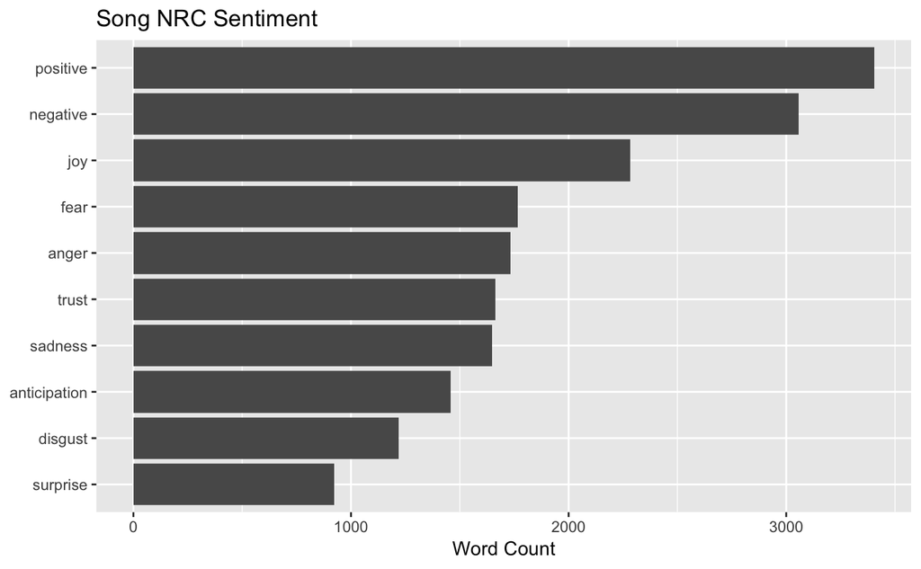

```r
All_songs_nrc %>%
  group_by(sentiment) %>%
  summarise(word_count = n()) %>%
  ungroup() %>%
  mutate(sentiment = reorder(sentiment, word_count)) %>%
  ggplot(aes(sentiment, word_count)) +
  geom_col() +
  labs(x = NULL, y = "Word Count") +
  ggtitle("Song NRC Sentiment") +
  coord_flip()
```

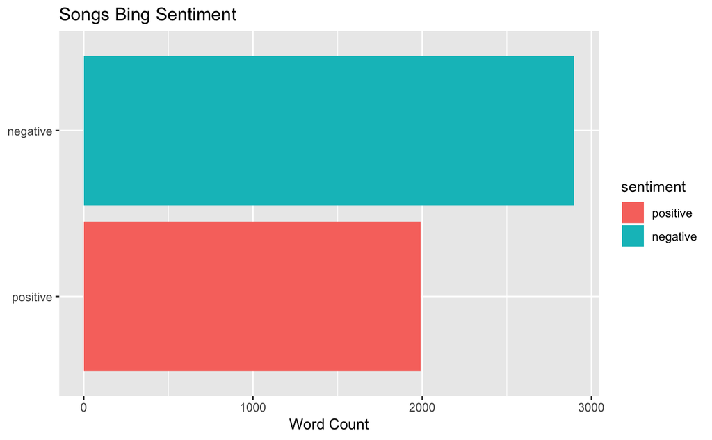

```r
All_songs_bing %>%
  group_by(sentiment) %>%
  summarise(word_count = n()) %>%
  ungroup() %>%
  mutate(sentiment = reorder(sentiment, word_count)) %>%
  ggplot(aes(sentiment, word_count, fill = sentiment)) +
  geom_col() +
  labs(x = NULL, y = "Word Count") +
  ggtitle("Songs Bing Sentiment") +
  coord_flip()
```

How do our love songs compare to the top100 songs now?

We can calculate polarity to get an idea:

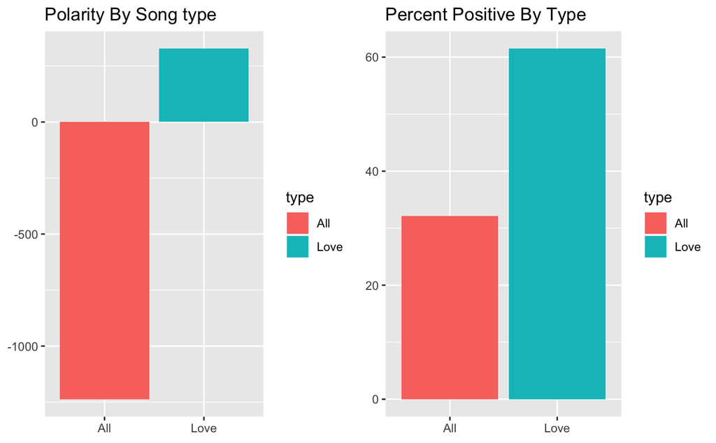

```r
song_polarity_chart <- All_songs_bing %>%
  count(sentiment, type) %>%
  spread(sentiment, n, fill = 0) %>%
  mutate(polarity = positive - negative,
    percent_positive = positive / (positive + negative) * 100)
plot1 <- song_polarity_chart %>%
  ggplot(aes(type, polarity, fill = type)) +
  geom_col() +
  xlab(NULL) + ylab(NULL) +
  ggtitle("Polarity By Song type")
plot2 <- song_polarity_chart %>%
  ggplot(aes(type, percent_positive, fill = type)) +
  geom_col() +
  xlab(NULL) + ylab(NULL) +
  ggtitle("Percent Positive By Type")
grid.arrange(plot1, plot2, ncol = 2)
```

It seems like our love songs are mostly positive, while the songs from our top100 chart are fairly negative. It could be really interesting to see how the sentiment of the top 100 songs has progressed over the years, especially if we can see how that may match historical events. But that’ll be for another time.

We can use the chordDiagram() to examine the relationships between NRC sentiments and song type.

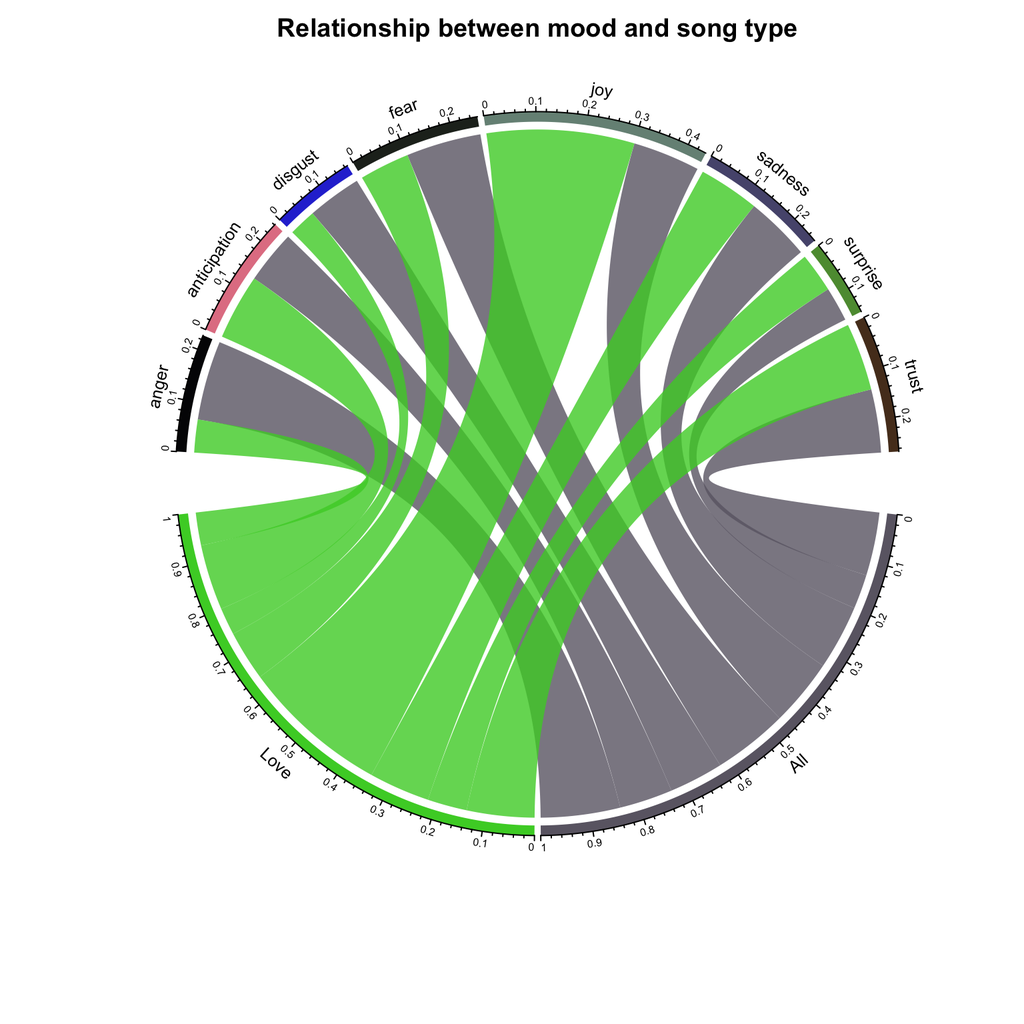

```r
type_mood <-  All_songs_nrc_sub %>%
    group_by(type,sentiment) %>%
    summarise(n = n()) %>%
    mutate(freq = n/sum(n)) %>%
    ungroup()
circos.clear()
chordDiagram(select(type_mood, type, sentiment, freq), transparency = .2)
title("Relationship between mood and song type")
```

We can also take a deeper look into the mood of specific songs. We can start with Whitney Houston’s I Will Always Love You.

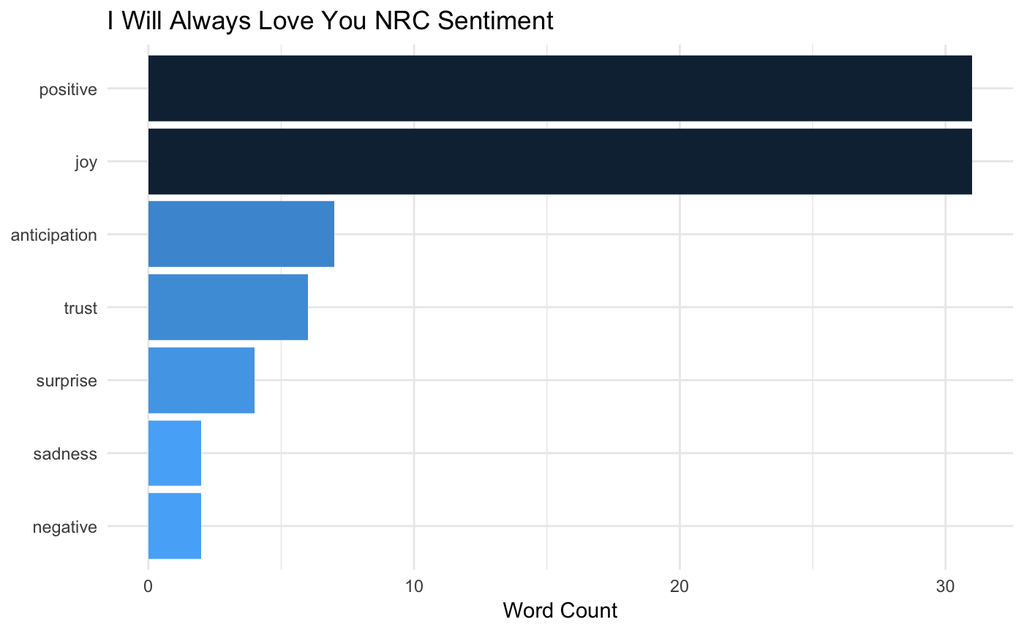

```r
All_songs_nrc %>%
  filter(track %in% "I Will Always Love You") %>%
  group_by(sentiment) %>%
  summarise(word_count = n()) %>%
  ungroup() %>%
  mutate(sentiment = reorder(sentiment, word_count)) %>%
  ggplot(aes(sentiment, word_count, fill = -word_count)) +
  geom_col() +
  guides(fill = FALSE) +
  theme_minimal() +
  labs(x = NULL, y = "Word Count") +
  ggtitle("I Will Always Love You NRC Sentiment") +
  coord_flip()
```

Compare that to Kendrick Lamar’s HUMBLE. from out top 100 chart:

[figure not shown]

```r
All_songs_nrc %>%
  filter(track %in% "HUMBLE.") %>%
  group_by(sentiment) %>%
  summarise(word_count = n()) %>%
  ungroup() %>%
  mutate(sentiment = reorder(sentiment, word_count)) %>%
  ggplot(aes(sentiment, word_count, fill = -word_count)) +
  geom_col() +
  guides(fill = FALSE) +
  theme_minimal() +
  labs(x = NULL, y = "Word Count") +
  ggtitle("I Will Always Love You NRC Sentiment") +
  coord_flip()
```

Using ggplot2 to create a slightly different chart, look at the words for each category.

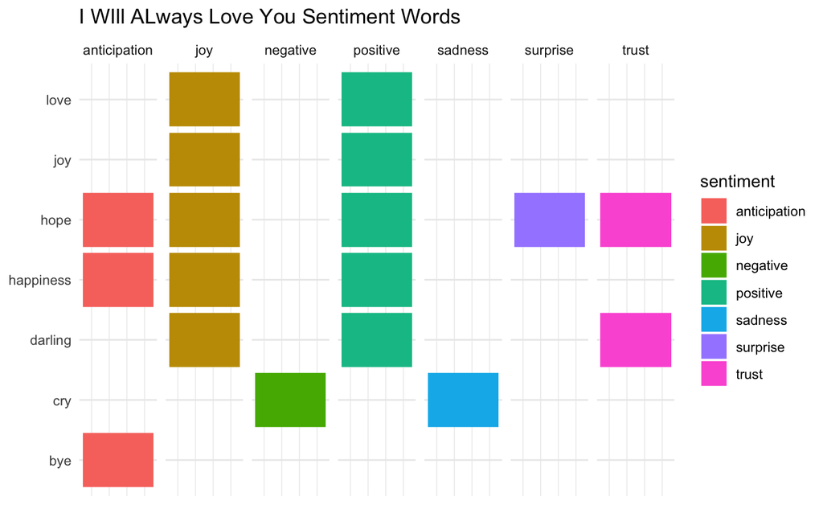

```r
All_songs_filtered %>%
  filter(track %in% 'I Will Always Love You') %>%
  distinct(word) %>%
  inner_join(get_sentiments("nrc")) %>%
  ggplot(aes(x = word, fill = sentiment)) +
  facet_grid(~sentiment) +
  geom_bar() + #Create a bar for each word per sentiment
  theme_minimal() +
  theme(panel.grid.major.x = element_blank(),
        axis.text.x = element_blank()) + #Place the words on the y-axis
  xlab(NULL) + ylab(NULL) +
  ggtitle("I WIll ALways Love You Sentiment Words") +
  coord_flip()
```

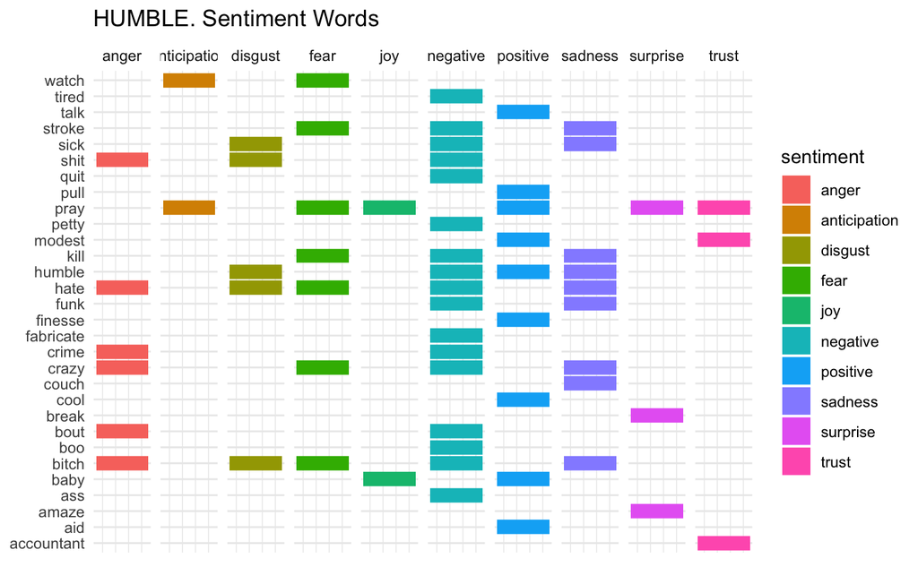

```r
All_songs_filtered %>%
  filter(track %in% 'HUMBLE.') %>%
  distinct(word) %>%
  inner_join(get_sentiments("nrc")) %>%
  ggplot(aes(x = word, fill = sentiment)) +
  facet_grid(~sentiment) +
  geom_bar() + #Create a bar for each word per sentiment
  theme_minimal() +
  theme(panel.grid.major.x = element_blank(),
        axis.text.x = element_blank()) + #Place the words on the y-axis
  xlab(NULL) + ylab(NULL) +
  ggtitle("HUMBLE. Sentiment Words") +
  coord_flip()
```

So far you have only been looking at unigrams or single words. But if “love” is a common word, what precedes it? Or follows it? Looking at single words out of context could be misleading. For example care could have a positive sentiment, while not care would be negative.

We don’t have time to repeat our analysis using bygrams, but it’s definitely something you should try!

Conveniently, the tidytext package provides the ability to unnest pairs of words as well as single words. In this case, you’ll call unnest_tokens() passing the token argument ngrams. Since you’re just looking at bigrams (two consecutive words), pass n = 2.

Try to play with sentiment analysis some more on your own and share your results with us later!

Thanks!